# Latihan Pertemuan 67

Ravi Mahesa Pramudya

2023-10-16

## Packages

```r
library(ggplot2)
library(tsibble)
library(tseries)
library(MASS)
library(forecast)
library(TSA)
library(TTR)
library(graphics)
```

## Input Data

```r
datasuhu <- read.csv("https://raw.githubusercontent.com/ravimahesa/ravimahesa/main/mpdw/data/pertemuan%207/Data%20Suhu%20Singapura%202010-2021.csv")
datasuhu
```

```
##     Periode  Suhu
## 1         1 26.63
## 2         2 27.68
## 3         3 27.94
## 4         4 28.58
## 5         5 29.08
## 6         6 28.01
## 7         7 27.61
## 8         8 27.32
## 9         9 27.76
## 10       10 27.62
## 11       11 27.32
## 12       12 26.28
## 13       13 25.62
## 14       14 26.15
```

[output cut: 130 more lines]

## ubah menjadi data time series

```r
dtsuhu.ts <- ts(datasuhu$Suhu)
summary(dtsuhu.ts)
```

```
##    Min. 1st Qu.  Median    Mean 3rd Qu.    Max.
##   25.50   27.20   27.49   27.51   27.95   29.17
```

## Membagi data menjadi data latih (80%) dan data uji (20%) dan jadikan time series

```r
dt.latih <- datasuhu[1:115,2]
dt.uji <- datasuhu[116:144,2]
dt.latih.ts <- ts(dt.latih, frequency = 12)
dt.uji.ts <- ts(dt.uji, frequency = 12)
```

# Eksplorasi data

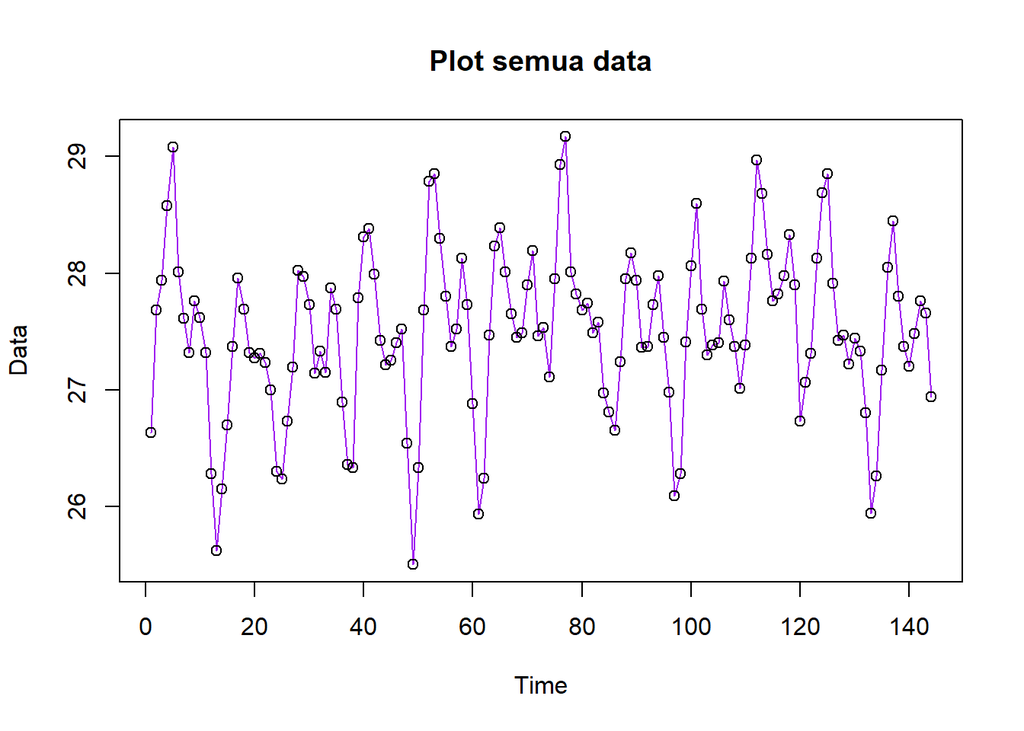

```r
# data full
ts.plot(dtsuhu.ts, col="purple",main="Plot semua data", type="o",xlab="Time",ylab="Data")
points(dtsuhu.ts)
```

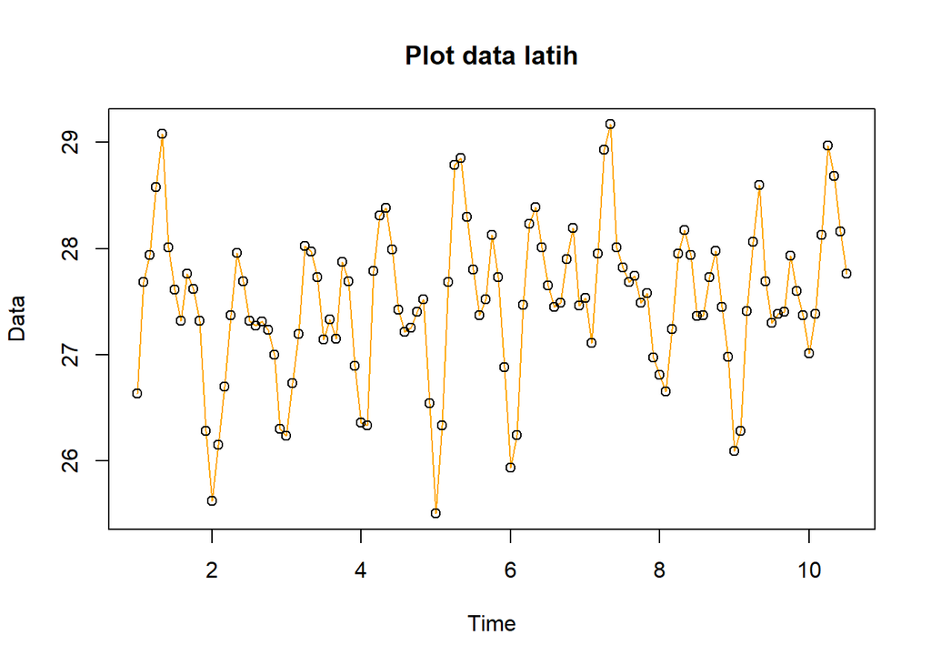

```r
# data latih
ts.plot(dt.latih.ts, col="orange",main="Plot data latih", type="o",xlab="Time",ylab="Data")
points(dt.latih.ts)
```

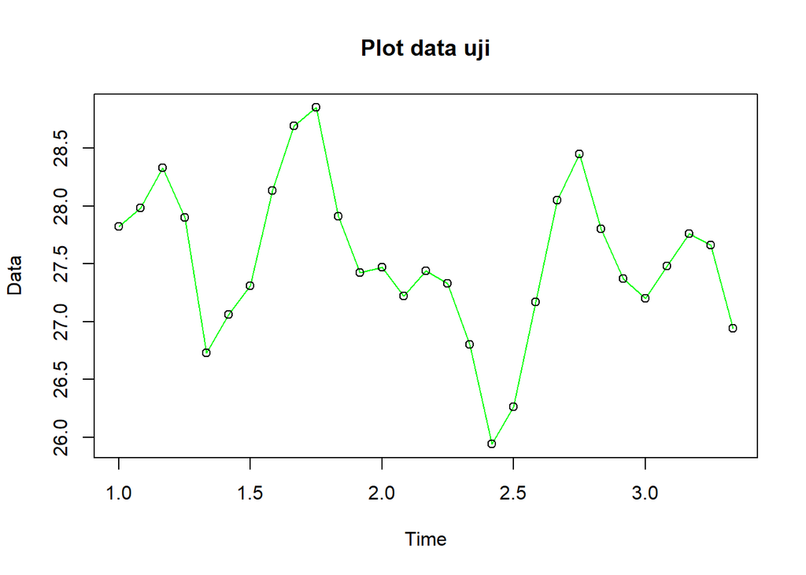

```r
# data uji
ts.plot(dt.uji.ts, col="green",main="Plot data uji", type="o",xlab="Time",ylab="Data")
points(dt.uji.ts)
```

# CEK Stasioner

### Plot acf

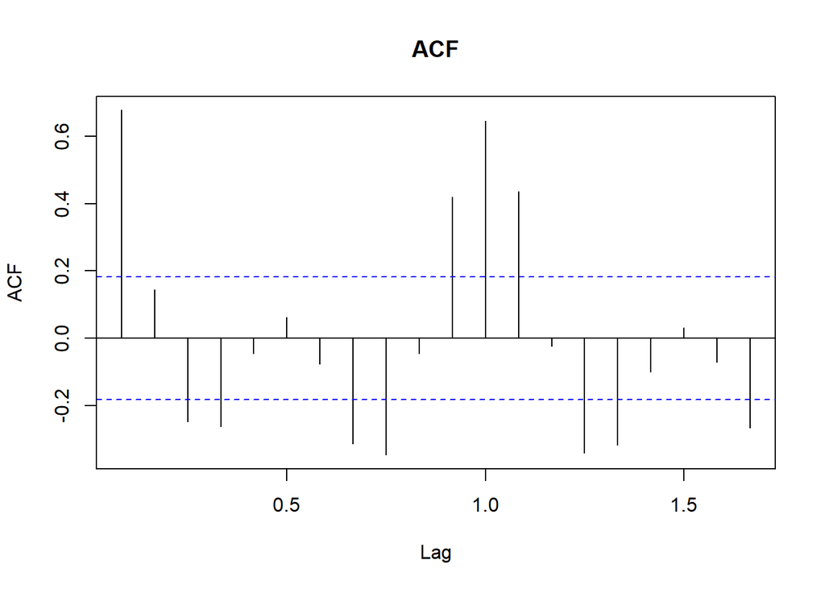

```r
acf(dt.latih.ts, main="ACF", lag.max=20)
```

Berdasarkan plot ACF, terlihat bahwa plot ACF pada data tersebut cenderung *tails off* dan membentuk gelombang sinus. menandakan bahwa data tersebut stasioner dalam rataan

### Uji ADF

```r
tseries::adf.test(dt.latih.ts)
```

```
##
##  Augmented Dickey-Fuller Test
##
## data:  dt.latih.ts
## Dickey-Fuller = -4.5619, Lag order = 4, p-value = 0.01
## alternative hypothesis: stationary
```

$H_0$ : Data tidak stasioner dalam rataan $H_1$ : Data stasioner dalam rataan

Berdasarkan uji ADF tersebut, didapat *p-value* sebesar 0.01 yang lebih kecil dari taraf nyata 5% sehingga tolak $H_0$ dan menandakan bahwa data stasioner dalam rataan. Hal ini sesuai dengan hasil eksplorasi menggunakan plot time series dan plot ACF.

### Plot Box-Cox

```r
index <- seq(1:115)
bc = boxcox(dt.latih.ts~index, lambda = seq(0,9,by=0.01))
```

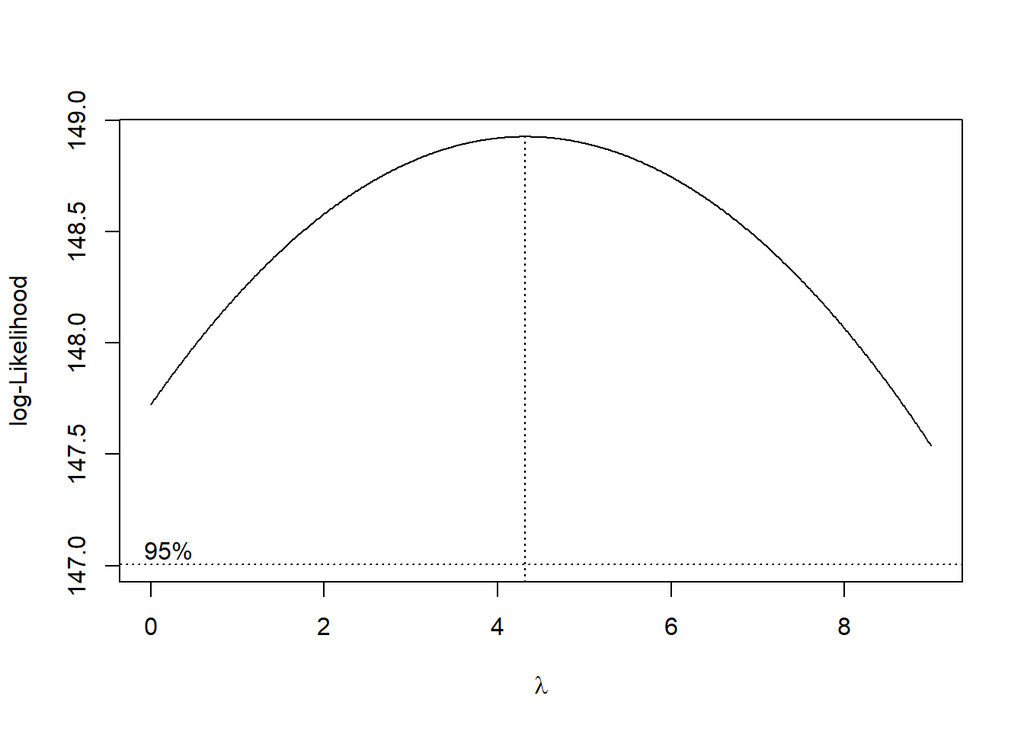

```r
#Nilai Rounded Lambda
lambda <- bc$x[which.max(bc$y)]
lambda
```

```
## [1] 4.32
```

```r
#SK
bc$x[bc$y > max(bc$y) - 1/2 * qchisq(.95,1)]
```

```
##   [1] 0.00 0.01 0.02 0.03 0.04 0.05 0.06 0.07 0.08 0.09 0.10 0.11 0.12 0.13 0.14
##  [16] 0.15 0.16 0.17 0.18 0.19 0.20 0.21 0.22 0.23 0.24 0.25 0.26 0.27 0.28 0.29
##  [31] 0.30 0.31 0.32 0.33 0.34 0.35 0.36 0.37 0.38 0.39 0.40 0.41 0.42 0.43 0.44
##  [46] 0.45 0.46 0.47 0.48 0.49 0.50 0.51 0.52 0.53 0.54 0.55 0.56 0.57 0.58 0.59
##  [61] 0.60 0.61 0.62 0.63 0.64 0.65 0.66 0.67 0.68 0.69 0.70 0.71 0.72 0.73 0.74
##  [76] 0.75 0.76 0.77 0.78 0.79 0.80 0.81 0.82 0.83 0.84 0.85 0.86 0.87 0.88 0.89
##  [91] 0.90 0.91 0.92 0.93 0.94 0.95 0.96 0.97 0.98 0.99 1.00 1.01 1.02 1.03 1.04
## [106] 1.05 1.06 1.07 1.08 1.09 1.10 1.11 1.12 1.13 1.14 1.15 1.16 1.17 1.18 1.19
## [121] 1.20 1.21 1.22 1.23 1.24 1.25 1.26 1.27 1.28 1.29 1.30 1.31 1.32 1.33 1.34
## [136] 1.35 1.36 1.37 1.38 1.39 1.40 1.41 1.42 1.43 1.44 1.45 1.46 1.47 1.48 1.49
## [151] 1.50 1.51 1.52 1.53 1.54 1.55 1.56 1.57 1.58 1.59 1.60 1.61 1.62 1.63 1.64
## [166] 1.65 1.66 1.67 1.68 1.69 1.70 1.71 1.72 1.73 1.74 1.75 1.76 1.77 1.78 1.79
## [181] 1.80 1.81 1.82 1.83 1.84 1.85 1.86 1.87 1.88 1.89 1.90 1.91 1.92 1.93 1.94
## [196] 1.95 1.96 1.97 1.98 1.99 2.00 2.01 2.02 2.03 2.04 2.05 2.06 2.07 2.08 2.09
## [211] 2.10 2.11 2.12 2.13 2.14 2.15 2.16 2.17 2.18 2.19 2.20 2.21 2.22 2.23 2.24
```

[output cut: 46 more lines]

Gambar di atas menunjukkan nilai *rounded value* ($\lambda$) optimum sebesar **4.32** dan pada selang kepercayaan 95% nilai memiliki batas bawah **0.00** dan batas atas **9.00**. Selang tersebut memuat nilai satu sehingga dapat dikatakan bahwa data bangkitan stasioner dalam ragam.

# Identifikasi model

### Plot ACF dan PACF

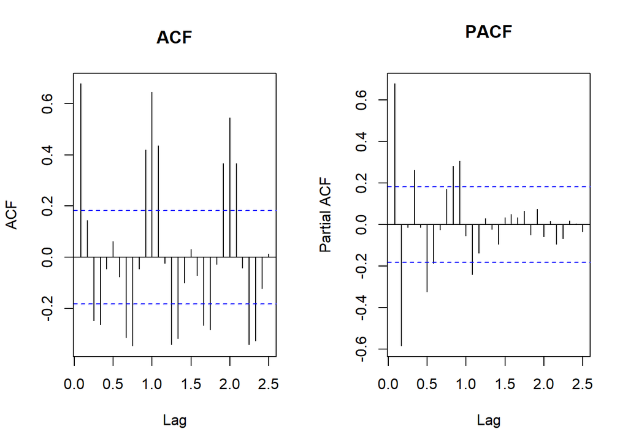

```r
par(mfrow = c(1,2))
acf(dt.latih.ts, main="ACF", lag.max=30) #ARIMA(0,0,2)
pacf(dt.latih.ts, main="PACF", lag.max=30) #ARIMA(1,0,0)
```

Berdasarkan plot tersebut, terlihat bahwa plot ACF cenderung cuts off pada lag ke 1, sehingga jika plot PACF dianggap tails of, maka model tentatifnya adalah ARIMA(0,0,1).

Berdasarkan plot tersebut, terlihat bahwa plot PACF cenderung cuts off pada lag ke 2, sehingga jika plot ACF dianggap tails of, maka model tentatifnya adalah ARIMA(2,0,0).

### Plot EACF

```r
eacf(dt.latih.ts)
```

```
## AR/MA
##   0 1 2 3 4 5 6 7 8 9 10 11 12 13
## 0 x o x x o o o x x o x  x  x  o
## 1 x x x x o o o x x o x  x  x  o
## 2 o x o o o o o o o o o  x  x  o
## 3 o x o o o o o o o o o  o  x  o
## 4 x x x o o o o o o o o  o  o  o
## 5 x x o o o o o o o o o  o  o  o
## 6 x x x o o o o o o o o  o  o  o
## 7 x x o o o o o o o o o  o  o  o
```

sehingga model tentafifnya ialah ARIMA(0,0,1), ARIMA(2,0,0)

# Pendugaan Parameter

### ARIMA (0,0,1)

```r
model1=Arima(dt.latih.ts, order=c(0,0,1),method="ML")
summary(model1) #AIC=176.83
```

```
## Series: dt.latih.ts
## ARIMA(0,0,1) with non-zero mean
##
## Coefficients:
##          ma1     mean
##       0.7376  27.4929
## s.e.  0.0496   0.0818
##
## sigma^2 = 0.2614:  log likelihood = -85.42
## AIC=176.83   AICc=177.05   BIC=185.07
##
## Training set error measures:
##                       ME      RMSE       MAE         MPE     MAPE     MASE
## Training set 0.003087761 0.5068149 0.3988257 -0.03110254 1.455365 0.938735
##                   ACF1
## Training set 0.3079317
```

```r
lmtest::coeftest(model1) #signifikan
```

```
##
## z test of coefficients:
##
##            Estimate Std. Error z value  Pr(>|z|)
## ma1        0.737585   0.049588  14.874 < 2.2e-16 ***
## intercept 27.492930   0.081819 336.023 < 2.2e-16 ***
## ---
## Signif. codes:  0 '***' 0.001 '**' 0.01 '*' 0.05 '.' 0.1 ' ' 1
```

### ARIMA (2,0,0)

```r
model2=Arima(dt.latih.ts, order=c(2,0,0),method="ML")
summary(model2) #AIC=132.46
```

```
## Series: dt.latih.ts
## ARIMA(2,0,0) with non-zero mean
##
## Coefficients:
##          ar1      ar2     mean
##       1.1108  -0.6188  27.4841
## s.e.  0.0739   0.0735   0.0760
##
## sigma^2 = 0.175:  log likelihood = -62.23
## AIC=132.46   AICc=132.82   BIC=143.44
##
## Training set error measures:
##                       ME      RMSE      MAE         MPE     MAPE      MASE
## Training set 0.003279425 0.4128003 0.329581 -0.01079278 1.202964 0.7757505
##                      ACF1
## Training set -0.005313901
```

```r
lmtest::coeftest(model2) #signifikan
```

```
##
## z test of coefficients:
##
##            Estimate Std. Error  z value  Pr(>|z|)
## ar1        1.110774   0.073861  15.0386 < 2.2e-16 ***
## ar2       -0.618809   0.073477  -8.4218 < 2.2e-16 ***
## intercept 27.484070   0.075963 361.8090 < 2.2e-16 ***
## ---
## Signif. codes:  0 '***' 0.001 '**' 0.01 '*' 0.05 '.' 0.1 ' ' 1
```

Penduga terbaik ialah aic terkecil dan parameter signifikan yang terdapat di ARIMA(2,0,0)

# analisis sisaan

### Eksplorasi

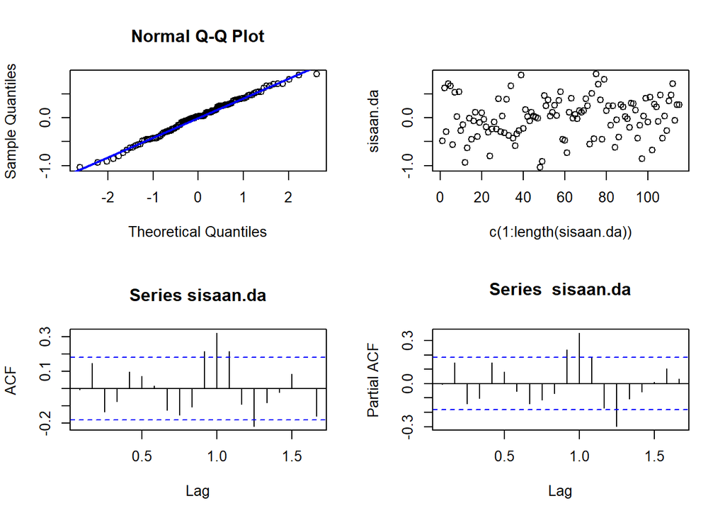

```r
#Eksplorasi
sisaan.da <- model2$residuals
par(mfrow=c(2,2))
qqnorm(sisaan.da)
qqline(sisaan.da, col = "blue", lwd = 2)
plot(c(1:length(sisaan.da)),sisaan.da)
acf(sisaan.da)
pacf(sisaan.da)
```

```r
par(mfrow = c(1,1))
```

### Uji Formal

```r
#1) Sisaan Menyebar Normal
ks.test(sisaan.da,"pnorm")
```

```
##
##  Asymptotic one-sample Kolmogorov-Smirnov test
##
## data:  sisaan.da
## D = 0.21768, p-value = 3.696e-05
## alternative hypothesis: two-sided
```

$H_0$ : Sisaan menyebar normal $H_1$ : Sisaan tidak menyebar normal

```r
#2) Sisaan saling bebas/tidak ada autokorelasi
Box.test(sisaan.da, type = "Ljung")
```

```
##
##  Box-Ljung test
##
## data:  sisaan.da
## X-squared = 0.0033328, df = 1, p-value = 0.954
```

$H_0$ : Sisaan saling bebas $H_1$ : Sisaan tidak tidak saling bebas

Berdasarkan uji Ljung-Box tersebut, didapat *p-value* sebesar 0.954 yang lebih besar dari taraf nyata 5% sehingga tak tolak $H_0$ dan menandakan bahwa sisaan saling bebas. Artinya tidak ada autokorelasi

```r
#3) Sisaan homogen
Box.test((sisaan.da)^2, type = "Ljung")
```

```
##
##  Box-Ljung test
##
## data:  (sisaan.da)^2
## X-squared = 3.3926, df = 1, p-value = 0.06549
```

$H_0$ : Ragam sisaan homogen $H_1$ : Ragam sisaan tidak homogen

Berdasarkan uji Ljung-Box tersebut. didapat *p-value* sebesar 0.06549 yang lebih besar dari taraf nyata 5% sehingga tak tolak $H_0$ dan menandakan bahwa ragam sisaan homogen

```r
#4) Nilai tengah sisaan sama dengan nol
t.test(sisaan.da, mu = 0, conf.level = 0.95)  #tak tolak h0 > nilai tengah sisaan sama dengan 0
```

```
##
##  One Sample t-test
##
## data:  sisaan.da
## t = 0.084825, df = 114, p-value = 0.9325
## alternative hypothesis: true mean is not equal to 0
## 95 percent confidence interval:
##  -0.07330785  0.07986670
## sample estimates:
##   mean of x
## 0.003279425
```

$H_0$ : nilai tengah sisaan sama dengan 0 $H_1$ : nilai tengah sisaan tidak sama dengan 0

Berdasarkan uji-ttersebut, didapat *p-value* sebesar 0.9325 yang lebih besar dari taraf nyata 5% sehingga tak tolak $H_0$ dan menandakan bahwa nilai tengah sisaan sama dengan 0.

# Overfitting

### ARIMA(2,0,1)

```r
model3=Arima(dt.latih.ts, order=c(2,0,1),method="ML")
summary(model3) #AIC=134.42
```

```
## Series: dt.latih.ts
## ARIMA(2,0,1) with non-zero mean
##
## Coefficients:
##          ar1      ar2     ma1     mean
##       1.0970  -0.6094  0.0225  27.4842
## s.e.  0.1033   0.0893  0.1153   0.0770
##
## sigma^2 = 0.1765:  log likelihood = -62.21
## AIC=134.42   AICc=134.97   BIC=148.14
##
## Training set error measures:
##                       ME      RMSE       MAE         MPE     MAPE      MASE
## Training set 0.003349502 0.4127304 0.3292377 -0.01052495 1.201617 0.7749424
##                    ACF1
## Training set -0.0169269
```

```r
lmtest::coeftest(model3) #Tidak signifikan
```

```
##
## z test of coefficients:
##
##            Estimate Std. Error  z value  Pr(>|z|)
## ar1        1.097020   0.103345  10.6151 < 2.2e-16 ***
## ar2       -0.609396   0.089304  -6.8239 8.862e-12 ***
## ma1        0.022456   0.115259   0.1948    0.8455
## intercept 27.484157   0.076976 357.0496 < 2.2e-16 ***
## ---
## Signif. codes:  0 '***' 0.001 '**' 0.01 '*' 0.05 '.' 0.1 ' ' 1
```

### ARIMA(3,0,0)

```r
model4=Arima(dt.latih.ts, order=c(3,0,0),method="ML")
summary(model4) #AIC=134.39
```

```
## Series: dt.latih.ts
## ARIMA(3,0,0) with non-zero mean
##
## Coefficients:
##          ar1      ar2     ar3     mean
##       1.1262  -0.6461  0.0246  27.4843
## s.e.  0.0945   0.1286  0.0950   0.0779
##
## sigma^2 = 0.1764:  log likelihood = -62.19
## AIC=134.39   AICc=134.94   BIC=148.11
##
## Training set error measures:
##                       ME      RMSE       MAE         MPE    MAPE      MASE
## Training set 0.003379352 0.4126764 0.3290114 -0.01039936 1.20072 0.7744099
##                     ACF1
## Training set -0.02588253
```

```r
lmtest::coeftest(model4) #Tidak signifikan
```

```
##
## z test of coefficients:
##
##            Estimate Std. Error  z value  Pr(>|z|)
## ar1        1.126214   0.094521  11.9149 < 2.2e-16 ***
## ar2       -0.646100   0.128563  -5.0256  5.02e-07 ***
## ar3        0.024604   0.095032   0.2589    0.7957
## intercept 27.484288   0.077855 353.0193 < 2.2e-16 ***
## ---
## Signif. codes:  0 '***' 0.001 '**' 0.01 '*' 0.05 '.' 0.1 ' ' 1
```

berdasarkan hasil overfitting yg terbaik tetap model ARIMA(2,0,0)

# Peramalan

```r
#---FORECAST---#
ramalan <- forecast::forecast(model2, h = 29)
ramalan
```

```
##        Point Forecast    Lo 80    Hi 80    Lo 95    Hi 95
## Aug 10       27.37229 26.83623 27.90836 26.55246 28.19213
## Sep 10       27.18917 26.38797 27.99036 25.96384 28.41449
## Oct 10       27.22567 26.35929 28.09204 25.90065 28.55068
## Nov 10       27.37953 26.51315 28.24591 26.05451 28.70455
## Dec 10       27.52785 26.63720 28.41851 26.16571 28.88999
## Jan 11       27.59739 26.67802 28.51677 26.19133 29.00346
## Feb 11       27.58285 26.65496 28.51075 26.16376 29.00195
## Mar 11       27.52367 26.59577 28.45157 26.10457 28.94277
## Apr 11       27.46693 26.53563 28.39823 26.04262 28.89124
## May 11       27.44053 26.50514 28.37591 26.00998 28.87108
## Jun 11       27.44631 26.50971 28.38291 26.01390 28.87872
## Jul 11       27.46907 26.53247 28.40568 26.03666 28.90148
## Aug 11       27.49078 26.55367 28.42788 26.05760 28.92396
## Sep 11       27.50080 26.56310 28.43850 26.06671 28.93489
## Oct 11       27.49850 26.56063 28.43638 26.06415 28.93286
## Nov 11       27.48975 26.55187 28.42763 26.05539 28.92411
## Dec 11       27.48145 26.54350 28.41940 26.04697 28.91592
## Jan 12       27.47764 26.53960 28.41568 26.04304 28.91225
## Feb 12       27.47855 26.54049 28.41662 26.04391 28.91320
## Mar 12       27.48192 26.54386 28.41998 26.04727 28.91657
## Apr 12       27.48510 26.54702 28.42317 26.05043 28.91976
## May 12       27.48654 26.54845 28.42463 26.05186 28.92122
## Jun 12       27.48618 26.54809 28.42427 26.05149 28.92087
## Jul 12       27.48488 26.54679 28.42298 26.05020 28.91957
## Aug 12       27.48367 26.54558 28.42176 26.04898 28.91836
## Sep 12       27.48312 26.54503 28.42122 26.04843 28.91781
## Oct 12       27.48326 26.54517 28.42136 26.04857 28.91796
## Nov 12       27.48376 26.54567 28.42186 26.04907 28.91846
## Dec 12       27.48423 26.54613 28.42232 26.04953 28.91892
```

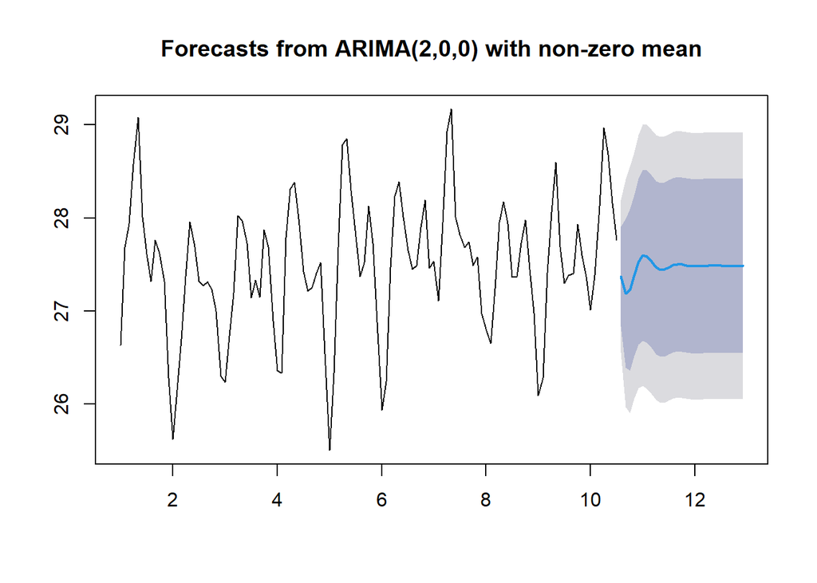

```r
data.ramalan <- ramalan$mean
plot(ramalan)
```

# AKURASI

```r
perbandingan <- matrix(data=c(head(dt.uji.ts, n=29), data.ramalan),
                     nrow = 29, ncol = 2)
colnames(perbandingan) <- c("Aktual","Hasil Forecast")
perbandingan
```

```
##       Aktual Hasil Forecast
##  [1,]  27.82       27.37229
##  [2,]  27.98       27.18917
##  [3,]  28.33       27.22567
##  [4,]  27.90       27.37953
##  [5,]  26.73       27.52785
##  [6,]  27.06       27.59739
##  [7,]  27.31       27.58285
##  [8,]  28.13       27.52367
##  [9,]  28.69       27.46693
## [10,]  28.85       27.44053
## [11,]  27.91       27.44631
## [12,]  27.42       27.46907
## [13,]  27.47       27.49078
## [14,]  27.22       27.50080
## [15,]  27.44       27.49850
## [16,]  27.33       27.48975
## [17,]  26.80       27.48145
## [18,]  25.94       27.47764
## [19,]  26.26       27.47855
## [20,]  27.17       27.48192
## [21,]  28.05       27.48510
## [22,]  28.45       27.48654
## [23,]  27.80       27.48618
## [24,]  27.37       27.48488
## [25,]  27.20       27.48367
## [26,]  27.48       27.48312
## [27,]  27.76       27.48326
## [28,]  27.66       27.48376
## [29,]  26.94       27.48423
```

```r
accuracy(data.ramalan[1:29], head(dt.uji.ts, n=29))
```

```
##                  ME      RMSE       MAE       MPE     MAPE      ACF1 Theil's U
## Test set 0.06857217 0.6884802 0.5425358 0.1903891 1.970165 0.6472104  1.275187
```